[figure not shown]

# Методы машинного обучения

### Шестаков Андрей (avshestakov@hse.ru)

## Тематические модели

- Тематическое моделирование - одно из современных направлений тематического анализа, активно развивающегося с конца 90-х годов.
- Идея ТМ схожа с идеей кластеризации - документы могут быть причислены к отпределенным тематикам, которые формируются на основе слов, из которых они состоят
- Хочется на выходе иметь тематическое представление каждого документа, и, желательно интерпретируемое представление каждой темы

[figure not shown]

## Приложения

- Тематический поиск
- Суммаризация и аннотирование текстовых документов
- Динамика тематик в предметной области на протяжении времени

[figure not shown]

## Предположения

- Порядок слов в документе и порядок документов в корпусе не важен (модель мешка слов)
- Каждый терм в документе связан с некоторой темой
- Документы и слова - наблюдаемые значения, тематики - скрытые значения

## Латентный семантический анализ (LSA)

- Основан на SVD разложении матрицы Документы-Слова

[figure not shown]

**Преимущества**

- Все просто
- Можно находить похожие слова через матрицу $V$ и похожие документы через матрицу $U$
- Есть практика использования LSA для задачи поиска (Latent Semantic Indexing)

**Недостатки**

- Плохо интерпретируется

# Вероятностный латентный семантический анализ (PLSA)¶

## Вероятностный латентный семантический анализ (PLSA)

- Каждый документ задает вероятностное распределение по темам - $p(t|d)$
- Каждая тема задает вероятностное распределение по словам - $p(w|t)$
- Распределение слов по темам не зависит от самого документа (только от его темы) $p(w|d,t) = p(w|t)$
- Документы в нашем корпусе текстов порождаются следующей вероятностной моделью
  - Сэмплируем документ $d$
  - Для каждого слова $w$ (а точнее места под слово) в документе:
    - Сэмплируем тематику $t$ из $p(t|d)$
    - Сэмплируем слово $w$ из $p(w|t)$ $$p(w,d) = p(d)p(w|d) = p(d)\sum_t p(w|t)p(t|d)$$
- Мы наблюдаем только $p(w|d)$ и предполагаем, что $$p(w|d) = \sum_t p(w|t)p(t|d) $$

## Вероятностный латентный семантический анализ (PLSA)

[figure not shown]

$$ p(w|d) = \sum_t p(w|t) p(t|d) = \sum_t\phi_{wt}\theta_{td}$$

- Максимизируется правдоподобие $$ P(D) = \prod_{d\in D}\prod_{w\in d} p(d,w)^{n_{dw}} $$

## Вероятностный латентный семантический анализ (PLSA)

- Если бы нам откуда-то были известны присваивания слов темам в каждом документе $p(t|d,w)$, то мы могли бы явно посчитать $p(w|t)$ и $p(t|d)$

[figure not shown]

## Вероятностный латентный семантический анализ (PLSA)

- Если бы нам откуда-то были известны присваивания слов темам в каждом документе $p(t|d,w)$, то мы могли бы явно посчитать $p(w|t)$ и $p(t|d)$
- Попытаемся оценить присваивания:

$$ p(t|d,w) = \frac{p(w,t|d)}{p(w|d)} = \frac{p(w|t)p(t|d)}{p(w|d)} = \frac{p(w|t)p(t|d)}{ \sum_t p(w|t) p(t|d)}$$

- Получается, если у нас есть $p(w|t)$ и $p(t|d)$, то мы можем оценить присваивания, а затем пересчитать $p(w|t)$ и $p(t|d)$!
- На что похожа эта процедура?

## EM-алгоритм

- **Инициализируем**
  - количество тем $T$
  - $p(w|t)$, $p(t|d)$ (или $\phi_{wt}$, $\theta_{td}$)
- **E-шаг**
  - Считаем $p_{tdw} = p(t|d,w)$
- **M-шаг**
  - Обновляем
  - $n_t = \sum\limits_d\sum\limits_w n_{dw} p_{tdw}$ (представленность тематики в корпусе - "количество" документов с тематикой $t$)
  - $n_{wt} = \sum\limits_w n_{dw} p_{tdw}$ ("количество" раз, когда слово $w$ относилось к тематике $t$)
  - $n_{dt} = \sum\limits_d n_{dw} p_{tdw}$ ("количество" раз, когда документ $d$ относился к тематике $t$)
  - $p(w|t) = \frac{n_{wt}}{n_t}$, $p(t|d) = \frac{n_{dt}}{n_t}$

## Вероятностный латентный семантический анализ (PLSA)

- PLSA так же формулируют в терминах неотрицательной матричной факторизации

[figure not shown]

Проблемы:

- Неединственность решения
- Нет управления разреженностью матриц $\Phi$ и $\Theta$
- Нет выделения общих тем и других механизмов, логичных в тематическом моделировании

# Латентное резмещение Дирихле (LDA)

## Распределение Дирихле

- "Распределение над распределениями"
- $ f(x_{1},\dots ,x_{K};\alpha _{1},\dots ,\alpha _{K})={\frac {1}{\mathrm {B} (\alpha )}}\prod _{i=1}^{K}x_{i}^{\alpha _{i}-1}$

[figure not shown]

```
<BarContainer object of 10 artists>
```

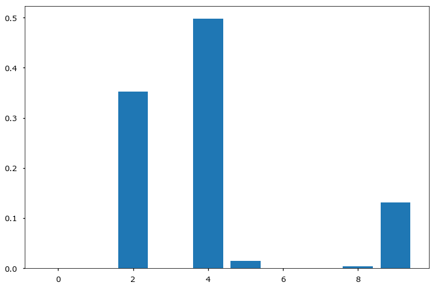

```python
from scipy.stats import dirichlet
alpha = 0.1
components = 10

a = np.empty((components,))
a.fill(alpha)
d = dirichlet(a)
plt.bar(range(components), d.rvs(size=1)[0])
```

## Латентное резмещение Дирихле (LDA)

- На документы и слова накладывается ограничение (регуляризация):
  - $\phi_{w} \sim Dir(\lambda)$
  - $\theta_{d} \sim Dir(\alpha)$
- Таким образом удается контролировать разреженность матриц $\Phi$ и $\Theta$

[figure not shown]

## LDA - процесс порождения слов в документе:

[figure not shown]

- Задаем количество тем $T$
- Сэмплируем документ $d$
- Сэмлируем распределение тем в документе: $\theta_{d} \sim Dir(\alpha)$
- Для каждого слова в документе:
  - Сэмлируем присваивание слова темe $z_{dw} = Multinomial(\theta_d)$
  - Сэмплируем само слово $w$ из $Multinomial(\phi_{z_{dw}})$
- Та же проблема - мы наблюдаем сами документы, а присванивания $z_{dw}$ нам не известны - мы должны их получить

## LDA - обучение

- Выполняется с помощью Gibbs Sampling (мат выкладки можно найти например [тут](http://www.ccs.neu.edu/home/vip/teach/DMcourse/5_topicmodel_summ/notes_slides/sampling/darling-lda.pdf))
- Инициализация: задаем количество тем $T$ и случайно присваиваем каждому слову в каждом документе тему
- Для каждого документа $d$ и каждого слова $w$ в нем считаем
  - $p(t|d)$ и $p(w|t)$, $t=1\dots T$
- Присваивания тем словам

[figure not shown]

- Распределение слов по темам

[figure not shown]

- Это не вероятности, но понятно, как из этих данных посчитать вероятности $p(t|d)$ и $p(w|t)$

## LDA - обучение (продолжение)

- Выполняется с помощью Gibbs Sampling (мат выкладки можно найти например [тут](http://www.ccs.neu.edu/home/vip/teach/DMcourse/5_topicmodel_summ/notes_slides/sampling/darling-lda.pdf))
- Инициализация: задаем количество тем $T$ и случайно присваиваем каждому слову в каждом документе тему
- Для каждого документа $d$ и каждого слова $w$ в нем считаем
  - $p(t|d)$ и $p(w|t)$, $t=1\dots T$
  - Выполняем переприсваивание метки темы для слова $w$
    - Вычитаем 1 из частоты слова $w$ в теме $z_{dw}$
    - Выбираем метку темы $k$ для слова $w$ в документе $d$ с вероятностью $$p(t=k|d,w) \propto p(k|d) p(w|k) = \frac{n_{dk} + \alpha_k}{\sum\limits_t (n_{dt} + \alpha_t)}\frac{n_{wt} + \lambda_w}{\sum\limits_{v\in{V}}(n_{vt} + \lambda_v)}$$
- Продолжаем, пока не выполнится какое-либо правило останова (макс количества операций, слабое изменение правдоподобия, и тп)

# ARTM

## Additive Regularization of Topic Models

Made by K.Vorontsov and team

## ARTM

- Более гибкая идеалогия работы с тематическим моделированием
- Основано на PLSA с различными регуляризаторами
  - Добавление фоновых тем
  - Разреживание предметных тем
  - Декорреляция тем
  - Работа с модальностями

[figure not shown]

# FYI

- [David Blei - topic modelling](https://www.youtube.com/watch?v=DDq3OVp9dNA)
- [Tutorial on probabilistic TM](http://machinelearning.ru/wiki/images/1/1f/Voron14aist.pdf)
- [Gensim - LDA](https://radimrehurek.com/gensim/models/ldamodel.html)
- [BigARTM](https://bigartm.readthedocs.io/en/stable/)